# The Welfare Cost of the 2017 Qatar Blockade: A Quantitative Trade Policy Analysis

SA

# The Welfare Cost of the 2017 Qatar Blockade: A Quantitative Trade Policy Analysis

Azizbek Abdullajonov, Sparsh Adhikari

2026-05-04

This analysis was completed for my class Quantitative Trade Models and made in collaboration with my friend Azizbek.

# 1. Data and Question

In June 2017, Saudi Arabia, the United Arab Emirates, Bahrain, and Egypt severed diplomatic relations with Qatar and imposed a comprehensive land, sea, and air blockade. The blockading states accused Qatar of supporting terrorism and maintaining close ties with Iran, charges Qatar denied. The blockade closed Qatar’s only land border with Saudi Arabia, restricted Qatari aircraft from neighboring airspace, and barred Qatari-flagged vessels from blockading states’ ports. The crisis lasted over three and a half years, ending with the Al-Ula Declaration in January 2021, which restored diplomatic ties and reopened borders.

**This project asks: what were the welfare effects of the 2017 blockade on Qatar and the wider Gulf region, and how much did Qatar’s trade diversification toward Turkey, Iran, and Oman offset the damage?**

Qatar is a small, open, energy-exporting economy with one of the highest GDP-per-capita figures in the world, driven primarily by liquefied natural gas exports. Prior to the blockade, Qatar was deeply integrated into the GCC economic area. Saudi Arabia controlled its only land border and served as a key transit route for food and construction materials. The UAE, particularly Dubai, functioned as a major re-export and logistics hub for Qatari imports. Intra-GCC trade in food, consumer goods, and industrial materials was substantial. The blockade severed these links abruptly.

We calibrate the model to 2016, the last available data year before the blockade, so that the baseline reflects normal pre-crisis trade relationships. The blockade is modeled as a severe increase in bilateral iceberg trade costs between Qatar and the four blockading states. An iceberg trade cost makes sure that goods become far more expensive to move between Qatar and the blockading states, but no government collects the difference.

We examine four scenarios to decompose the blockade’s impact:

1. **Full blockade** — near-prohibitive trade costs between Qatar and Saudi Arabia, the UAE, Bahrain, and Egypt
2. **Blockade + mild diversion** — full blockade combined with a 10% reduction in trade costs between Qatar and Turkey, Iran, and Oman
3. **Blockade + moderate diversion** — full blockade combined with a 20% reduction in trade costs with the same alternative partners
4. **Blockade + strong diversion** — full blockade combined with a 30% reduction in trade costs with alternative partners

By comparing these scenarios, we can separate the raw cost of the blockade from the offsetting benefit of Qatar’s diversification response, and test how sensitive the results are to the assumed magnitude of trade cost reductions with alternative partners.

The country set includes all six GCC states individually (Qatar, Saudi Arabia, UAE, Kuwait, Oman, Bahrain), Egypt, Turkey, Iran, and major global trading partners (China, Japan, India, the EU, and the United States), for a total of 14 named regions plus Rest of World.

# 2. Setup

```r
config <- eora_config(eora_rds_path = "eora_data.rds", template_root = ".")
# ---- Baseline year: 2016 (last year before the June 2017 blockade)
config$Calibration_Year <- 2016

# ---- Baseline tariffs
config$Tariff_Year <- 2016

# ---- Trade balance treatment
config$balanced_trade <- TRUE

# ---- Numeraire country -----------------------------------------------------
config$Normalize_Country <- "USA"

# ---- Countries --------------------------------------------------------------
config$countries <- pick_countries(
  "GCC",
  add = c("EGY", "TUR", "IRN",                # blockade + diversion partners
          "CHN", "JPN", "IND", "EUU", "USA")   # major global partners
)

show_picked(config$countries)
```

```
## 14 named entries selected plus ROW (15 model regions total):
##  ISO3          Name
##   QAT         Qatar
##   ARE           UAE
##   SAU  Saudi Arabia
##   KWT        Kuwait
##   OMN          Oman
##   BHR       Bahrain
##   EGY         Egypt
##   TUR        Turkey
##   IRN          Iran
##   CHN         China
##   JPN         Japan
##   IND         India
##   EUU            EU
##   USA United States
```

```r
# ---- Counterfactual scenarios ------------------------------------------------
# The 2017 blockade is modeled as a massive increase in iceberg trade costs
# between Qatar and the four blockading states (SAU, ARE, BHR, EGY).
# Factor = 50 makes trade nearly prohibitive without numerical issues.
#
# Trade diversion scenarios reduce trade costs between Qatar and alternative
# partners (TUR, IRN, OMN) at three levels to test sensitivity.

blockade_shocks <- list(
  list(type = "iceberg_change", country1 = "QAT", country2 = "SAU",
       factor = 50, symmetric = TRUE),
  list(type = "iceberg_change", country1 = "QAT", country2 = "ARE",
       factor = 50, symmetric = TRUE),
  list(type = "iceberg_change", country1 = "QAT", country2 = "BHR",
       factor = 50, symmetric = TRUE),
  list(type = "iceberg_change", country1 = "QAT", country2 = "EGY",
       factor = 50, symmetric = TRUE)
)

diversion_mild <- list(
  list(type = "iceberg_change", country1 = "QAT", country2 = "TUR",
       factor = 0.9, symmetric = TRUE),
  list(type = "iceberg_change", country1 = "QAT", country2 = "IRN",
       factor = 0.9, symmetric = TRUE),
  list(type = "iceberg_change", country1 = "QAT", country2 = "OMN",
       factor = 0.9, symmetric = TRUE)
)

diversion_moderate <- list(
  list(type = "iceberg_change", country1 = "QAT", country2 = "TUR",
       factor = 0.8, symmetric = TRUE),
  list(type = "iceberg_change", country1 = "QAT", country2 = "IRN",
       factor = 0.8, symmetric = TRUE),
  list(type = "iceberg_change", country1 = "QAT", country2 = "OMN",
       factor = 0.8, symmetric = TRUE)
)

diversion_strong <- list(
  list(type = "iceberg_change", country1 = "QAT", country2 = "TUR",
       factor = 0.7, symmetric = TRUE),
  list(type = "iceberg_change", country1 = "QAT", country2 = "IRN",
       factor = 0.7, symmetric = TRUE),
  list(type = "iceberg_change", country1 = "QAT", country2 = "OMN",
       factor = 0.7, symmetric = TRUE)
)

scenarios <- list(
  "Full blockade"              = blockade_shocks,
  "Blockade + mild diversion"  = c(blockade_shocks, diversion_mild),
  "Blockade + moderate diversion" = c(blockade_shocks, diversion_moderate),
  "Blockade + strong diversion"   = c(blockade_shocks, diversion_strong)
)
```

## 2.1 Load and inspect the data

```r
ModelData <- initialize_model_data_eora(config)
cat("Sectors:", ModelData$S, " Model regions:", ModelData$J, "\n")
```

```
## Sectors: 10  Model regions: 15
```

```r
knitr::kable(
  data.frame(
    Code = ifelse(ModelData$Country_List == "EUU", "EU", ModelData$Country_List),
    Name = country_name(ModelData$Country_List),
    row.names = NULL
  ),
  caption = "Model regions", row.names = FALSE
)
```

Model regions

| Code | Name |
| --- | --- |
| ARE | UAE |
| BHR | Bahrain |
| CHN | China |
| EGY | Egypt |
| EU | EU |
| IND | India |
| IRN | Iran |
| JPN | Japan |
| KWT | Kuwait |
| OMN | Oman |
| QAT | Qatar |
| ROW | Rest of World |
| SAU | Saudi Arabia |
| TUR | Turkey |
| USA | United States |

```r
if (!is.null(ModelData$sector_names)) {
  knitr::kable(ModelData$sector_names[1:ModelData$S, ],
               caption = "Traded sectors and elasticities")
}
```

Traded sectors and elasticities

| sector | sector_name | is_traded |
| --- | --- | --- |
| 1 | Agriculture and Fishing | TRUE |
| 2 | Mining and Quarrying | TRUE |
| 3 | Food and Beverages | TRUE |
| 4 | Textiles and Apparel | TRUE |
| 5 | Wood and Paper | TRUE |
| 6 | Petroleum/Chemical/Non-Metallic Minerals | TRUE |
| 7 | Metal Products | TRUE |
| 8 | Electrical and Machinery | TRUE |
| 9 | Transport Equipment | TRUE |
| 10 | Other Manufacturing | TRUE |

We include all six GCC states individually because the blockade divided the bloc. Qatar was the target while Saudi Arabia, the UAE, and Bahrain were the imposers, and Kuwait and Oman remained neutral. Egypt is included as the fourth blockading state. Turkey, Iran, and Oman are included because they served as Qatar’s primary alternative trade partners during the crisis. China, Japan, India, the EU, and the United States are Qatar’s largest non-regional trading partners and capture the global dimension of trade adjustment. We calibrate to 2016 because it is the last available data year before the blockade began in June 2017.

# 3. Counterfactual and Results

## 3.1 Calibrate and solve the baseline

```r
ModelVar_Calibrated <- calibrate_model(ModelData, config)
res_calib <- equilibrium_solve(ModelVar_Calibrated)
ModelVar_Calibrated <- res_calib$ModelVar
stopifnot(res_calib$exitflag > 0)

if (isTRUE(config$balanced_trade)) {
  message("Setting D = 0 for balanced-trade baseline...")
  ModelVar_Baseline <- apply_balanced_trade(ModelVar_Calibrated)
  res_base <- equilibrium_solve(ModelVar_Baseline)
  ModelVar_Baseline <- res_base$ModelVar
  stopifnot(res_base$exitflag > 0)
  ModelVar_Baseline$Welfare_Baseline <- ModelVar_Baseline$Welfare
} else {
  ModelVar_Baseline <- ModelVar_Calibrated
}
```

## 3.2 Run counterfactuals

We run 4 scenario(s): Full blockade, Blockade + mild diversion, Blockade + moderate diversion, Blockade + strong diversion.

```r
all_results <- list()
all_cev     <- list()
for (nm in names(scenarios)) {
  message("Scenario: ", nm)
  MV_cf <- build_counterfactual(ModelVar_Baseline, scenarios[[nm]])
  res_cf <- equilibrium_solve(MV_cf)
  stopifnot(res_cf$exitflag > 0)
  all_results[[nm]] <- summarize_results(ModelVar_Baseline, res_cf$ModelVar, label = nm)
  all_cev[[nm]]     <- compute_welfare_cev(ModelVar_Baseline, res_cf$ModelVar)
  all_cev[[nm]]$scenario <- nm
}
all_results <- do.call(rbind, all_results)
all_cev     <- do.call(rbind, all_cev)
```

## 3.3 Results table

```r
library(tidyr)

focal <- c("QAT", "SAU", "ARE", "BHR", "EGY", "OMN", "TUR", "IRN")
top <- unique(
  all_results$country[order(abs(all_results$welfare_pct_change), decreasing = TRUE)]
)
display_countries <- unique(c(focal, head(setdiff(top, focal), 3)))
display <- all_results[all_results$country %in% display_countries, ]

wide <- display %>%
  select(name, scenario, welfare_pct_change) %>%
  pivot_wider(names_from = scenario, values_from = welfare_pct_change)

knitr::kable(wide, digits = 3,
  caption = "Welfare change (%) — key countries across scenarios")
```

Welfare change (%) — key countries across scenarios

| name | Full blockade | Blockade + mild diversion | Blockade + moderate diversion | Blockade + strong diversion |
| --- | --- | --- | --- | --- |
| UAE | 0.835 | 0.845 | 0.862 | 0.890 |
| Bahrain | 0.818 | 0.821 | 0.827 | 0.837 |
| Egypt | -1.855 | -1.855 | -1.855 | -1.855 |
| India | 0.367 | 0.366 | 0.364 | 0.362 |
| Iran | 0.410 | 0.429 | 0.463 | 0.523 |
| Kuwait | -1.311 | -1.313 | -1.316 | -1.322 |
| Oman | 0.662 | 0.742 | 0.878 | 1.120 |
| Qatar | -2.311 | -2.071 | -1.670 | -0.941 |
| Saudi Arabia | 0.182 | 0.182 | 0.183 | 0.183 |
| Turkey | -1.167 | -1.160 | -1.147 | -1.123 |
| United States | -3.339 | -3.339 | -3.340 | -3.340 |

## 3.4 Consumption Equivalent Variation (CEV)

CEV measures welfare change using **baseline preferences** — the correct metric when the counterfactual changes preferences or sector shares. When preferences don’t change, CEV equals the standard welfare measure.

```r
cev_wide <- all_cev %>%
  filter(country %in% display_countries) %>%
  select(name, scenario, cev_pct) %>%
  pivot_wider(names_from = scenario, values_from = cev_pct)

knitr::kable(cev_wide, digits = 3,
  caption = "CEV (%) — consumption equivalent variation")
```

CEV (%) — consumption equivalent variation

| name | Full blockade | Blockade + mild diversion | Blockade + moderate diversion | Blockade + strong diversion |
| --- | --- | --- | --- | --- |
| UAE | 0.835 | 0.845 | 0.862 | 0.890 |
| Bahrain | 0.818 | 0.821 | 0.827 | 0.837 |
| Egypt | -1.855 | -1.855 | -1.855 | -1.855 |
| India | 0.367 | 0.366 | 0.364 | 0.362 |
| Iran | 0.410 | 0.429 | 0.463 | 0.523 |
| Kuwait | -1.311 | -1.313 | -1.316 | -1.322 |
| Oman | 0.662 | 0.742 | 0.878 | 1.120 |
| Qatar | -2.311 | -2.071 | -1.670 | -0.941 |
| Saudi Arabia | 0.182 | 0.182 | 0.183 | 0.183 |
| Turkey | -1.167 | -1.160 | -1.147 | -1.123 |
| United States | -3.339 | -3.339 | -3.340 | -3.340 |

## 3.5 Welfare chart

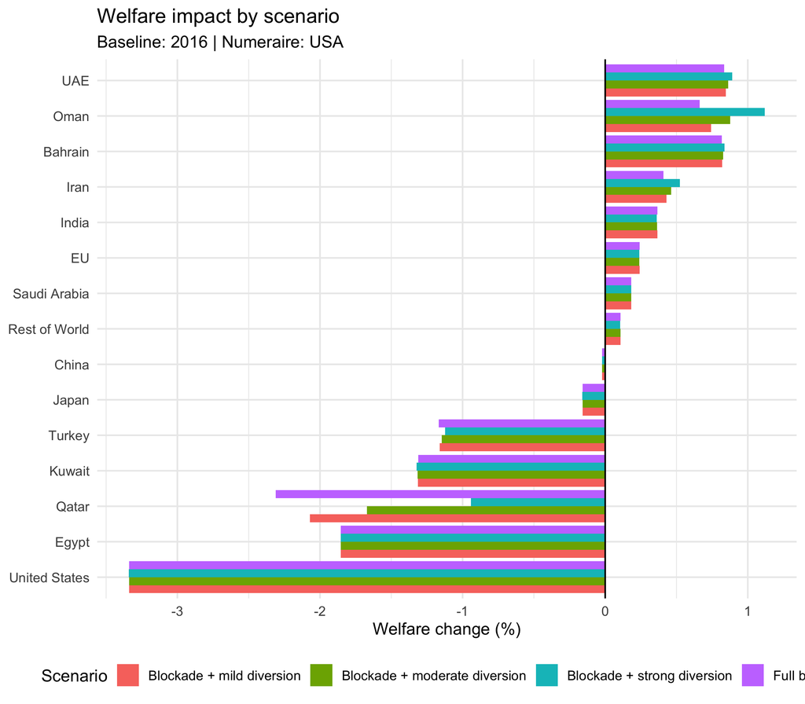

```r
plot_welfare_report(
  all_results,
  title = "Welfare impact by scenario",
  subtitle = paste("Baseline:", config$Calibration_Year,
                   "| Numeraire:", config$Normalize_Country)
)
```

The model produces several clear patterns. Qatar, the target of the blockade, suffers the largest welfare loss among Gulf states at -2.311% under the full blockade scenario. This reflects the loss of cheap, geographically proximate trade with its neighbors, particularly the closure of the Saudi land border, which was Qatar’s primary route for food and construction material imports. However, the diversion scenarios show that Qatar can recover a substantial portion of this loss by establishing alternative trade routes: with strong diversion (a 30% reduction in trade costs with Turkey, Iran, and Oman), Qatar’s welfare loss falls to just -0.941%, recovering roughly 60% of the blockade damage.

Among the blockading states, the results are mixed. Saudi Arabia experiences a very small gain (+0.18%), consistent with its large, diversified economy being relatively insulated from the loss of a small trading partner. The UAE (+0.84%) and Bahrain (+0.82%) also gain, which most likely reflects trade diversion as Qatar’s trade with the blockading states collapses. The UAE and Bahrain probably absorb some of the regional trade that previously flowed through Qatar. Egypt, the fourth blockading state, loses -1.86%, likely because it loses bilateral trade with Qatar without gaining enough from trade diversion elsewhere to compensate.

The neutral GCC states respond as expected. Oman gains (+0.66%), and its gains increase with stronger diversion (+1.12%), consistent with its real-world role as Qatar’s primary alternative shipping gateway during the crisis. Iran also gains modestly (+0.41%), reflecting its role in providing airspace and food supplies to Qatar.

Two results require caution. Turkey shows a welfare loss of -1.17% despite being one of Qatar’s strongest supporters during the blockade. This is because the full blockade scenario does not reduce trade costs between Qatar and Turkey — it only raises costs with the blockading states. Turkey is hurt through general equilibrium effects as the regional disruption reduces overall economic activity. In the diversion scenarios, Turkey’s losses do shrink, which is the expected pattern. The United States shows a -3.3% welfare loss, which is implausibly large for a country with minimal direct trade exposure to the Qatar-GCC corridor. This is likely an artifact of the balanced-trade assumption interacting with the numeraire choice (the US wage is fixed at 1, so global price adjustments are absorbed asymmetrically), and should not be interpreted as a realistic estimate.

## 3.6 Wage changes

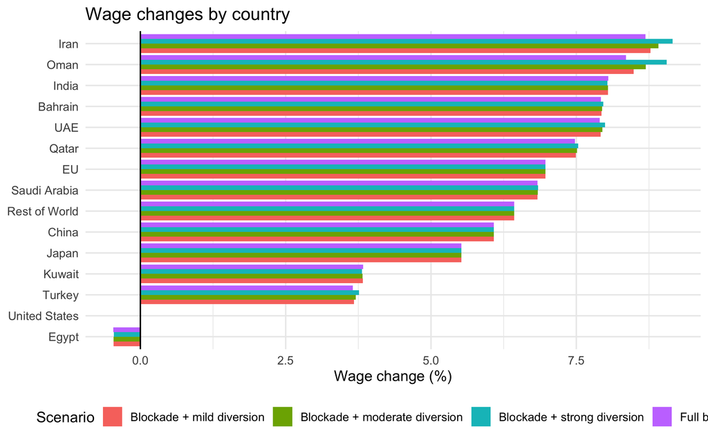

```r
library(ggplot2)
wage_df <- all_results %>%
  mutate(wage_pct = 100 * (wage_cf / wage_baseline - 1))

ggplot(wage_df, aes(x = reorder(name, wage_pct), y = wage_pct, fill = scenario)) +
  geom_col(position = "dodge") +
  geom_hline(yintercept = 0) +
  coord_flip() +
  labs(title = "Wage changes by country",
       x = NULL, y = "Wage change (%)", fill = "Scenario") +
  theme_minimal(base_size = 12) +
  theme(legend.position = "bottom")
```

# 4. Comparison to Other Sources

The 2017 Qatar blockade is a historical event with well-documented economic outcomes, which allows us to compare the model’s predictions against what actually occurred. We compare along two dimensions: the direction and magnitude of bilateral trade changes in the EORA data, and the broader economic impact documented in IMF reports, academic studies, and news coverage of the crisis.

## 4.1 What does the data show?

```r
all_countries <- config$countries[config$countries != "QAT"]

actual_list <- list()
for (c2 in all_countries) {
  tryCatch({
    res <- actual_trade_change(
      eora_rds_path = "eora_data.rds",
      country1 = "QAT",
      country2 = c2,
      year_before = 2016,
      year_after  = 2019,
      agg_countries = config$countries
    )
    actual_list[[c2]] <- res
  }, error = function(e) NULL)
}

actual_all <- do.call(rbind, actual_list)
knitr::kable(actual_all,
  caption = "Actual trade changes: Qatar vs all partners (2016 to 2019)")
```

Actual trade changes: Qatar vs all partners (2016 to 2019)

| source | destination | y2016 | y2019 | pct_change |
| --- | --- | --- | --- | --- |
| ARE | QAT | 7402161 | 5905878 | -20.21 |
| QAT | ARE | 1747856 | 1974649 | 12.98 |
| QAT | SAU | 949613 | 1117793 | 17.71 |
| SAU | QAT | 1721002 | 2223906 | 29.22 |
| KWT | QAT | 472877 | 532498 | 12.61 |
| QAT | KWT | 521677 | 612673 | 17.44 |
| OMN | QAT | 370136 | 525964 | 42.10 |
| QAT | OMN | 49775 | 61517 | 23.59 |
| BHR | QAT | 677899 | 639375 | -5.68 |
| QAT | BHR | 83450 | 110671 | 32.62 |
| EGY | QAT | 203138 | 290481 | 43.00 |
| QAT | EGY | 87892 | 111097 | 26.40 |
| QAT | TUR | 29831 | 33676 | 12.89 |
| TUR | QAT | 288033 | 287961 | -0.02 |
| IRN | QAT | 692390 | 603791 | -12.80 |
| QAT | IRN | 43924 | 56341 | 28.27 |
| CHN | QAT | 4260627 | 3966365 | -6.91 |
| QAT | CHN | 4326585 | 5684280 | 31.38 |
| JPN | QAT | 3207588 | 2632326 | -17.93 |
| QAT | JPN | 17404092 | 22334969 | 28.33 |
| IND | QAT | 3927756 | 4028167 | 2.56 |
| QAT | IND | 823443 | 1205456 | 46.39 |
| EUU | QAT | 13584196 | 12290721 | -9.52 |
| QAT | EUU | 463378 | 589474 | 27.21 |
| QAT | USA | 3899139 | 4984881 | 27.85 |
| USA | QAT | 5850055 | 5308991 | -9.25 |

Several patterns in the data do align with the model’s predictions. Oman’s exports to Qatar increased by 42%, consistent with the model’s prediction that Oman gains from trade diversion. Qatar’s exports to China (+31%), India (+46%), and Japan (+28%) all increased substantially, consistent with Qatar redirecting trade toward non-regional partners. Prior to the blockade, only about 15 percent of Qatari imports came from the blockading countries, and these imports were highly fungible and could be procured from many other sources (Livingston & Saha, 2017).

Comparing to external sources, the IMF’s 2018 Article IV Consultation found that Qatar’s growth performance remained resilient and described the direct economic and financial impact of the diplomatic rift as “manageable” (IMF, 2018). Non-hydrocarbon real GDP growth moderated to about 4 percent in 2017, while overall real GDP growth was 2.1 percent, only slightly below the 2.2 percent recorded in 2016 (IMF, 2018). The World Bank similarly estimated that growth slowed to 2 percent in 2017, noting that the hydrocarbon sector, which constitutes 80 percent of export earnings and 90 percent of government revenues, was largely unaffected (World Bank, 2017). This suggests the actual welfare impact could have been much smaller than the model’s -2.3% estimate for a full blockade, but qualitatively in the right direction. The model correctly predicts that Qatar is hurt, but overstates the magnitude because it assumes all sectors are equally disrupted.

## 4.2 Executive summary

The model-based approach adds three things beyond simple trade data analysis. First, it provides a welfare measure that accounts for general equilibrium effects, when Qatar’s trade is disrupted, wages, prices, and consumption adjust across all countries simultaneously, producing winners and losers that a bilateral trade table cannot identify. Second, the multi-scenario comparison allows us to decompose the blockade’s impact into the raw cost of trade disruption and the offsetting benefit of diversification, showing that trade diversion through Oman, Turkey, and Iran could recover up to 60% of Qatar’s welfare loss. Third, the model highlights its own limitations: by applying uniform trade cost increases across all sectors, it overstates the impact of a blockade that primarily affected non-energy trade while leaving Qatar’s dominant LNG sector largely untouched. This comparison between model predictions and observed data demonstrates both the value and the boundaries of quantitative trade policy analysis. The model correctly identifies the direction and broad pattern of effects, but its assumption of uniform trade disruption produces magnitudes that exceed what actually occurred in an economy where the blockaded sectors represent only a fraction of total trade.

# Appendix: Full Results

```r
knitr::kable(
  all_results %>%
    select(name, scenario, wage_cf, welfare_pct_change) %>%
    pivot_wider(names_from = scenario,
                values_from = c(wage_cf, welfare_pct_change)),
  digits = 4,
  caption = "Full results: wages and welfare changes"
)
```

Full results: wages and welfare changes

| name | wage_cf_Full blockade | wage_cf_Blockade + mild diversion | wage_cf_Blockade + moderate diversion | wage_cf_Blockade + strong diversion | welfare_pct_change_Full blockade | welfare_pct_change_Blockade + mild diversion | welfare_pct_change_Blockade + moderate diversion | welfare_pct_change_Blockade + strong diversion |
| --- | --- | --- | --- | --- | --- | --- | --- | --- |
| UAE | 0.7963 | 0.7965 | 0.7967 | 0.7970 | 0.8350 | 0.8451 | 0.8619 | 0.8900 |
| Bahrain | 0.7945 | 0.7946 | 0.7947 | 0.7948 | 0.8176 | 0.8210 | 0.8270 | 0.8373 |
| China | 0.7836 | 0.7836 | 0.7836 | 0.7836 | -0.0217 | -0.0219 | -0.0222 | -0.0229 |
| Egypt | 0.7278 | 0.7278 | 0.7278 | 0.7278 | -1.8554 | -1.8553 | -1.8551 | -1.8548 |
| EU | 0.7802 | 0.7802 | 0.7802 | 0.7802 | 0.2411 | 0.2407 | 0.2399 | 0.2386 |
| India | 0.8121 | 0.8121 | 0.8121 | 0.8120 | 0.3667 | 0.3658 | 0.3643 | 0.3620 |
| Iran | 0.7849 | 0.7855 | 0.7865 | 0.7883 | 0.4096 | 0.4294 | 0.4634 | 0.5235 |
| Japan | 0.7893 | 0.7893 | 0.7893 | 0.7893 | -0.1582 | -0.1586 | -0.1592 | -0.1602 |
| Kuwait | 0.7620 | 0.7620 | 0.7619 | 0.7619 | -1.3113 | -1.3132 | -1.3165 | -1.3221 |
| Oman | 0.7973 | 0.7983 | 0.7998 | 0.8025 | 0.6617 | 0.7422 | 0.8776 | 1.1197 |
| Qatar | 0.7921 | 0.7922 | 0.7923 | 0.7925 | -2.3105 | -2.0714 | -1.6696 | -0.9412 |
| Rest of World | 0.7910 | 0.7910 | 0.7910 | 0.7910 | 0.1078 | 0.1075 | 0.1069 | 0.1060 |
| Saudi Arabia | 0.7841 | 0.7841 | 0.7842 | 0.7842 | 0.1825 | 0.1825 | 0.1826 | 0.1827 |
| Turkey | 0.7587 | 0.7589 | 0.7591 | 0.7595 | -1.1670 | -1.1596 | -1.1469 | -1.1234 |
| United States | 1.0000 | 1.0000 | 1.0000 | 1.0000 | -3.3392 | -3.3393 | -3.3395 | -3.3399 |

# 5. References

Livingston, D., & Saha, S. (2017). Beyond the Qatar crisis. *Carnegie Endowment for International Peace*. https://carnegieendowment.org/middle-east/diwan/2017/08/beyond-the-qatar-crisis

International Monetary Fund. (2018). Qatar: 2018 Article IV Consultation — Press Release; Staff Report; and Statement by the Executive Director for Qatar. *IMF Country Report No. 18/135*. https://www.imf.org/en/publications/cr/issues/2018/05/30/qatar-2018-article-iv-consultation-press-release-staff-report-and-statement-by-the-executive-45915

Kapar, B., & Buigut, S. (2020). Effect of Qatar diplomatic and economic isolation on Qatar stock market volatility: An event study approach. Applied Economics, 52(55), 6042–6054. https://doi.org/10.1080/00036846.2020.1781776

Neubauer, S. (2017). How Qatar seeks to establish new trade routes. *The Washington Institute for Near East Policy*. https://www.washingtoninstitute.org/policy-analysis/how-qatar-seeks-establish-new-trade-routes

World Bank. (2017). Qatar’s economic outlook — October 2017. *World Bank Gulf Economic Monitor*. https://www.worldbank.org/en/country/gcc/publication/qatar-economic-outlook-october-2017